# Benchmark

Ruben Heradio (rheradio@issi.uned.es)

Date: 2021-02-17

# 1 Initialization

## 1.1 Importing packages and installing them if needed

# 2 Benchmark

The samplers were tested against a benchmark composed of 218 models encoded as Boolean formulas in all of the following formats:

- *DIMACS*, which is the format QuickSampler, Smarch, Spur, and Unigen2 use as input. These samplers rely on SAT technology, and DIMACS is the format for *Conjunctive Normal Form* (CNF) formulas that SAT technology uses.
- *DDDMP*, which is the format BDDSampler uses for BDDs.
- *NNF*, which is the format KUS uses for d-DNNFs.

Nine of the 218 models represent configurable software systems. The remaining models are industrial SAT formulas (mostly modeling integrated circuits) that are typically used as a benchmark in the SAT-sampling literature [1]–[3].

The experiments were run on an Intel(R) Core(TM) i7-6700HQ, 2.60GHz, 16GB RAM, operating Linux Ubuntu 19.10. Samplers were executed on a single thread (i.e., with no parallelization), and without considering any Boolean formulas’ preprocessing, such as formula’s *Minimal Independent Support* (MIS) [4].

## 2.1 The number of variables and clauses are highly correlated

```
## [1] "Pearson's r:"
```

```
## [1] 0.9661694
```

```
##
## Call:
## lm(formula = clauses ~ vars, data = log_data)
##
## Residuals:
##     Min      1Q  Median      3Q     Max
## -1.8202 -0.2044 -0.0237  0.1261  3.8409
##
## Coefficients:
##             Estimate Std. Error t value Pr(>|t|)
## (Intercept)  1.35308    0.15533   8.711 7.94e-16 ***
## vars         1.02778    0.01867  55.057  < 2e-16 ***
## ---
## Signif. codes:  0 '***' 0.001 '**' 0.01 '*' 0.05 '.' 0.1 ' ' 1
##
## Residual standard error: 0.4854 on 216 degrees of freedom
## Multiple R-squared:  0.9335, Adjusted R-squared:  0.9332
## F-statistic:  3031 on 1 and 216 DF,  p-value: < 2.2e-16
```

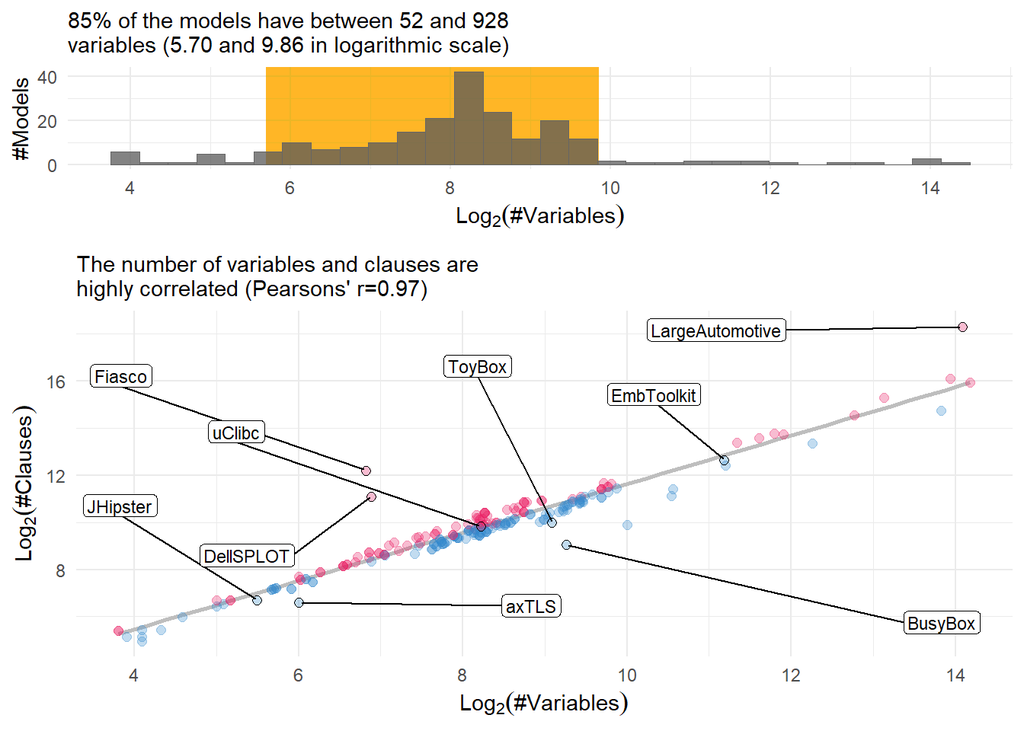

## 2.2 Detailed information

The following table summarizes the benchmark.

| model | vars | clauses |
| --- | --- | --- |
| blasted_case200 | 14 | 42 |
| blasted_case206 | 14 | 42 |
| blasted_case60 | 15 | 35 |
| s27_new_15_7 | 17 | 43 |
| s27_new_3_2 | 17 | 31 |
| s27_new_7_4 | 17 | 35 |
| s27_3_2 | 20 | 43 |
| s27_7_4 | 24 | 63 |
| blasted_case103 | 32 | 86 |
| s27_15_7 | 32 | 103 |
| blasted_case102 | 34 | 92 |
| blasted_case127 | 36 | 104 |
| blasted_case128 | 36 | 104 |
| jhipster | 45 | 104 |
| blasted_case28 | 51 | 143 |
| blasted_case33 | 51 | 143 |
| blasted_case27 | 52 | 146 |
| blasted_case32 | 52 | 146 |
| blasted_case26 | 53 | 148 |
| blasted_case31 | 53 | 148 |
| blasted_case134 | 60 | 146 |
| blasted_case137 | 60 | 146 |
| axtls | 64 | 96 |
| blasted_case36 | 64 | 208 |
| blasted_case24 | 65 | 190 |
| blasted_case29 | 65 | 190 |
| blasted_case25 | 68 | 195 |
| blasted_case30 | 68 | 195 |
| blasted_case100 | 72 | 178 |
| blasted_case101 | 72 | 178 |

[output cut: 188 more lines]

# References

[1] S. Chakraborty, D. J. Fremont, K. S. Meel, S. A. Seshia, and M. Y. Vardi, “On parallel scalable uniform SAT witness generation,” in *21st international conference on tools and algorithms for the construction and analysis of systems (tacas)*, 2015, pp. 304–319.

[2] D. Achlioptas, Z. S. Hammoudeh, and P. Theodoropoulos, “Fast sampling of perfectly uniform satisfying assignments,” in *21st international conference on theory and applications of satisfiability testing (sat)*, 2018, pp. 135–147.

[3] Q. Plazar, M. Acher, G. Perrouin, X. Devroey, and M. Cordy, “Uniform Sampling of SAT Solutions for Configurable Systems: Are We There Yet?” in *12th ieee conference on software testing, validation and verification (icst)*, 2019, pp. 240–251.

[4] A. Ivrii, S. Malik, K. S. Meel, and M. Y. Vardi, “On computing minimal independent support and its applications to sampling and counting,” *Constraints*, vol. 21, no. 1, pp. 41–58, 2016.